# Part II - (Prosper Loans Explanatory Analysis)

## Key Insights

> - Relationship between the main features(BorrowerAPR and Loan Amount):The BorrowerAPR helps a borrower determine the true cost of the loan. From analysis there was a negative relationship which means that one variable tends to cause a decrease in another variable. The more money you borrow, the lower your BorrowerAPR
> - Prosper Rating Effect on Relationship between BorrowerAPR and Loan Amount: ProsperRating is a significant measure of loan amount and BorrowerAPR. ProsperRating tells us how risky the borrower is. Having a good ProsperRating can help to increase a borrower’s loan amount and improve BorrowerAPR. Since most of the loans is for debt consolidation, the ProsperRating is normally distributed.
> - Term Effect on Loan Amount: There is positive correlation between Term and Loan Amount. The higher the loan, the longer the term.
> - IncomeRange effect on Loan Amount and BorrowerAPR: The income of borrowers played a significant role in determining the loan amount which also affects the BorrowerAPR. Borrowers with good sources of income can borrow large loans.

## Dataset Overview

> The prosper loan dataset contains 113,937 loans with 81 variables on each loan, including loan amount, borrower rate (or interest rate), loan status, borrower income, borrower employment status, borrower credit history, and the latest payment information.

### Data Analysis Steps

> - I cleaned and selected 14 features from the dataset after understanding the features provided in the Prosper variables definitions file.
> - I used Question-Visualization-Observations framework to narrate by exploration
> - I defined functions to avoid repetitive coding.
> - I extracted a sample of 1000 observations for some multivariate analysis to get a clearer picture.
> - I saved the cleaned data as *prosper_loan_master.csv*

## Distribution of Borrower APR

> APR appears to have a multimodal distribution. A small peak at 0.1 and a large peak at 0.2. There is also a minor peak at 0.3. There is also a very shape peak between 0.35 and 0.36. Only a few loans have an APR higher than 0.43.

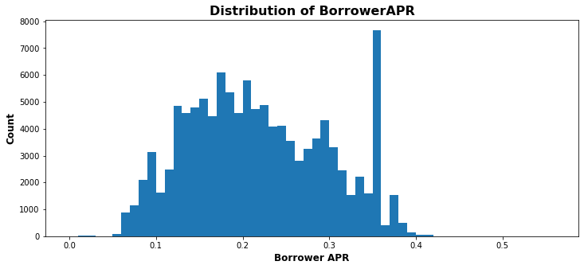

## Distribution of Loan Original Amount

> The very large spikes in frequency are at 4k, 5k, 8k, 10k, 15k, 20k, 25k. It means that most of the loans are multiples of 5k.

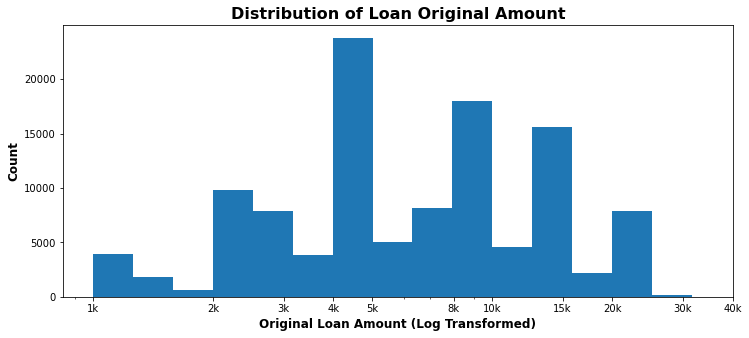

## Distribution of ProsperRating

> There is a normal distribution in the ratings. The lowest risked loan is AA and highest risked loan is HR, and NC is No Credit rating.

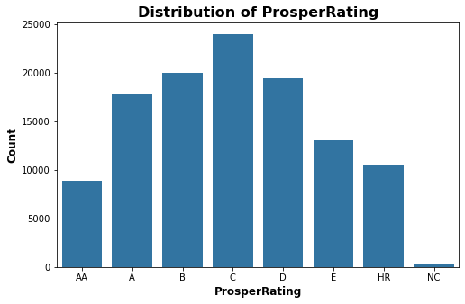

## Distribution of IncomeRange

> Most of the loans are given to income earners.

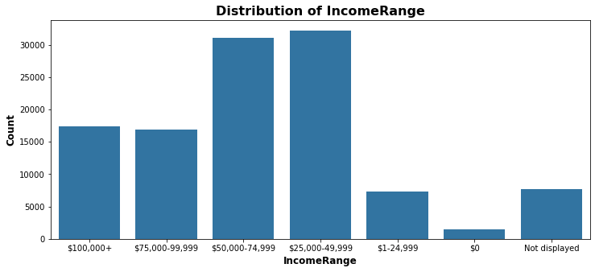

## Distribution of Loan Purposes

> Most of the loans are refinancing debts.

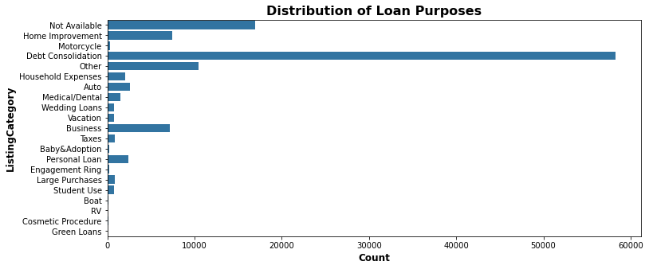

## Distribution of Loans across Time

> There is a significant growth in loan disbursements in recent years

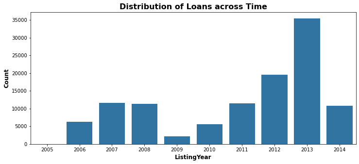

## Distribution of Loan Term

> Most of the loans are intermediate loans

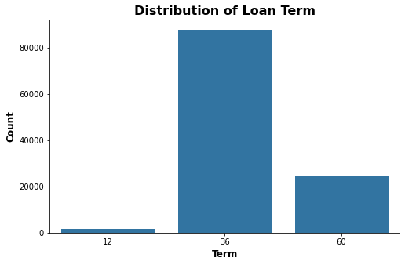

## Relationship between Borrower APR and Loan Amount

> A negative correlation means the increase in one variable tends to cause a decrease in another variable. This means that the more the loan amount, the lower the Borrower APR.

```
the correlation between BorrowerAPR and Original Loan Amount is: -0.32285850125087506.
```

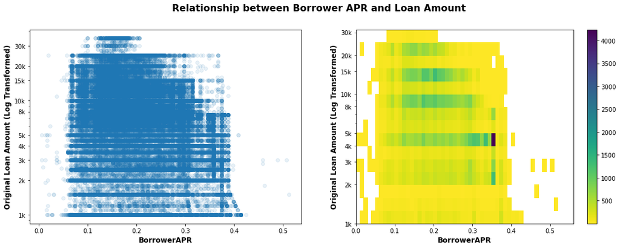

## Distribution of IncomeRange across years

> Income range plays significant role in loan disbursements. From the plot, we notice that borrowers with no income ranges were not given loans after 2007 and borrowers that did not have source of income were not given loans in 2014

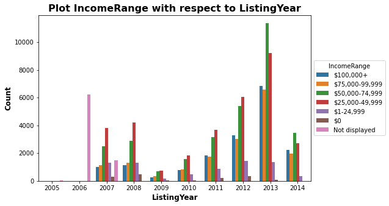

## Prosper Rating Effect on Relationship between BorrowerAPR and Loan Amount

> ProsperRating is a major factor in determining the loan amount and BorrowerAPR. The better your ratings, the better your APR and loan amount

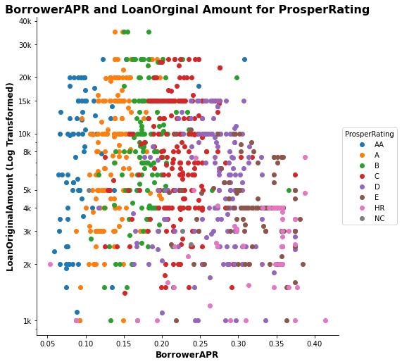

## Term Effect on Relationship between BorrowerAPR and Loan Amount

> High value loans are attached to longer terms.

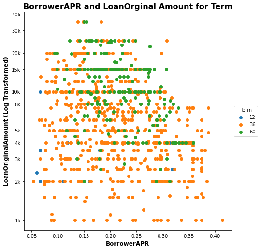

## Income Effect on Relationship between BorrowerAPR and Loan Amount

> The income of borrowers has a major effect on borrowerAPR and Loan Amount. The more the borrowers earn, the more loan he gets.

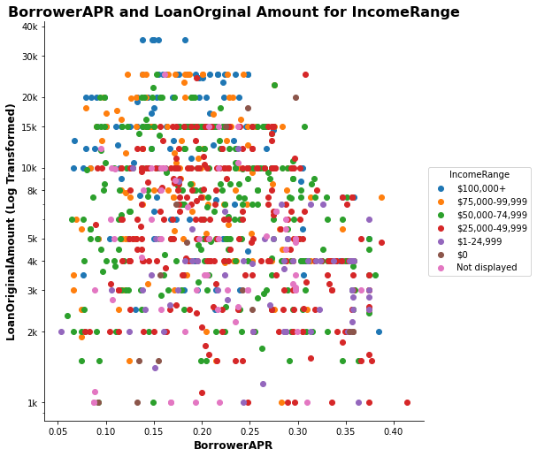

## Relationship between BorrowerAPR and ProsperRating and loan status

> There is an increase in BorrowerAPR as the loan gets more risky. The Defaulted loans in the least riskest loan has a higher APR.

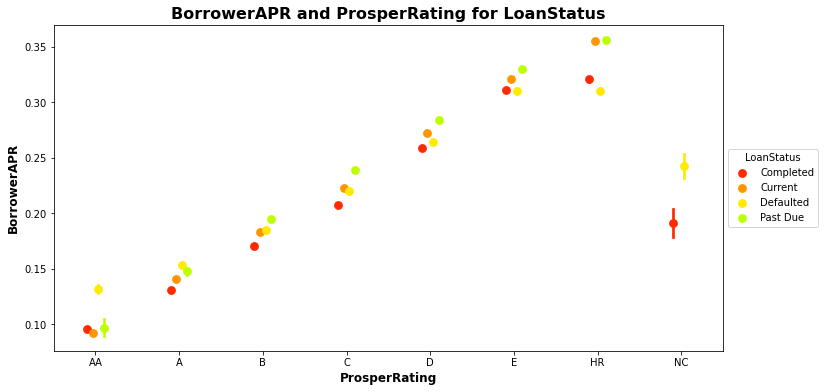

## Relationship between ProsperRating, Loan Amount and Loan Status

> The decline in loan amount corresponds to the rating, Risky loans have small loan value. There are no current loans with no grade.

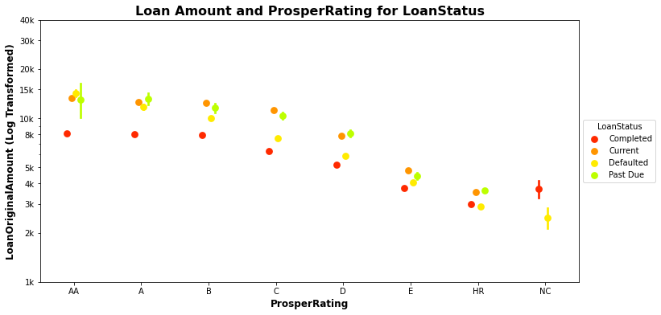